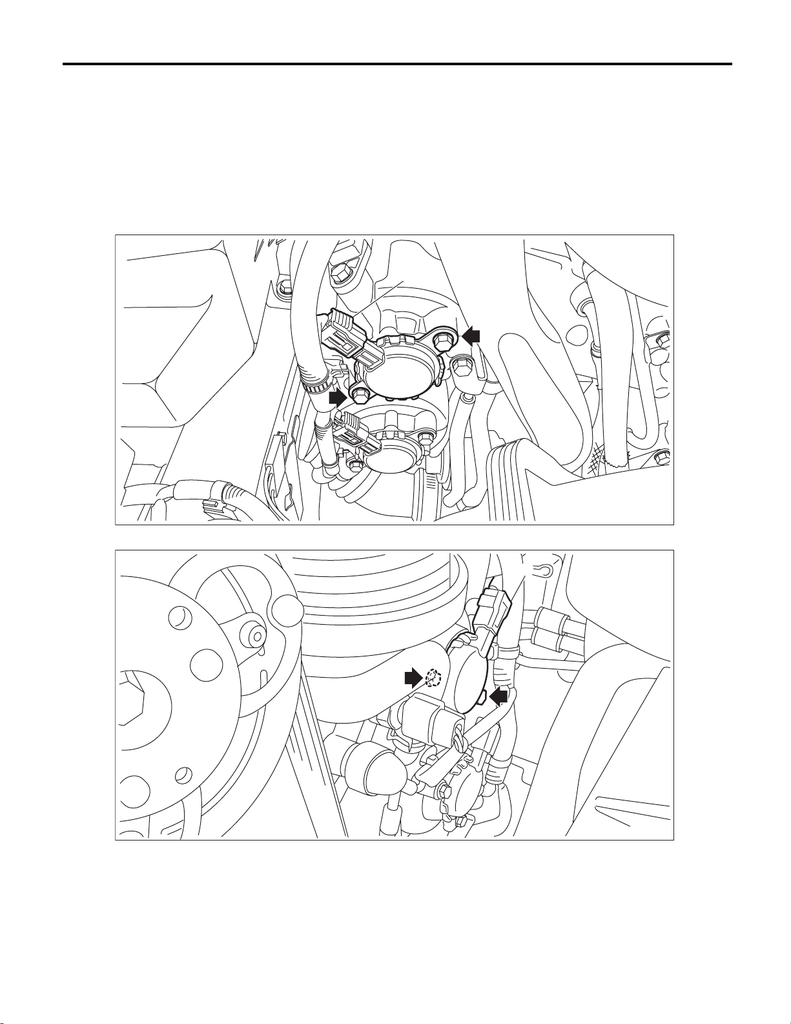

FU(w/o STI)-108

Oil Control Solenoid

FUEL INJECTION (FUEL SYSTEMS)

16.Oil Control Solenoid

A: REMOVAL

1. INTAKE SIDE

1) Disconnect the ground terminal from battery sensor. <Ref. to NT-5, BATTERY, NOTE, Note.>

2) Remove the air intake duct. (RH side only) <Ref. to IN(w/o STI)-22, REMOVAL, Air Intake Duct.>

3) Disconnect the connector (A) from the oil control solenoid, and remove the oil control solenoid from the

chain cover.

• RH side

•LH side

FU-08488

(A)

(A)

FU-07973

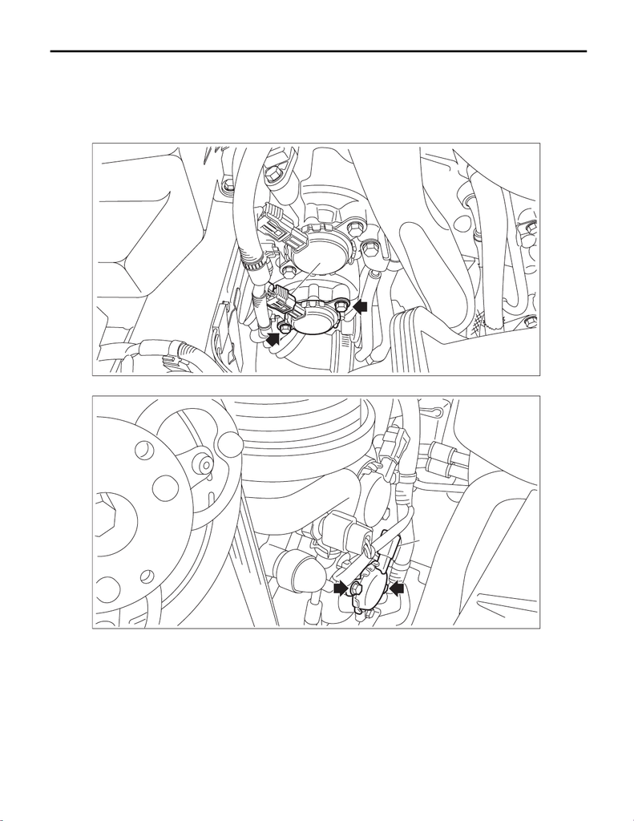

FU(w/o STI)-109

Oil Control Solenoid

FUEL INJECTION (FUEL SYSTEMS)

2. EXHAUST SIDE

1) Disconnect the ground terminal from battery sensor. <Ref. to NT-5, BATTERY, NOTE, Note.>

2) Remove the air intake duct. (RH side only) <Ref. to IN(w/o STI)-22, REMOVAL, Air Intake Duct.>

3) Disconnect the connector (A) from the oil control solenoid, and remove the oil control solenoid from the

chain cover.

• RH side

•LH side

B: INSTALLATION

Install in the reverse order of removal.

NOTE:

• Use new O-rings.

• Apply engine oil to O-ring.

Tightening torque:

6.4 N·m (0.7 kgf-m, 4.7 ft-lb)

FU-08489

(A)

(A)

FU-07974

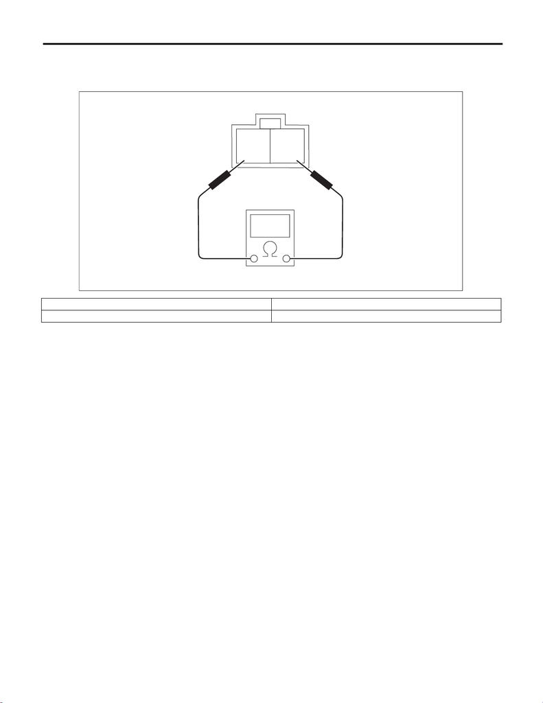

FU(w/o STI)-110

Oil Control Solenoid

FUEL INJECTION (FUEL SYSTEMS)

C: INSPECTION

1) Check that the oil control solenoid has no deformation, cracks or other damages.

2) Measure the resistance between the oil control solenoid terminals.

Terminal No. Standard

1 and 2 7.25±0.4 Ω (when 20°C (68°F))

FU-05950

2

1